# event study bnps only

Devraj Kori

3/13/2020

Event study possible specification
$$Y_{i,ht} = \sum_{\tau=-q}^m(\beta_{\tau}D^{\tau}_{i,h,t}) + \theta_{h} + \psi_t + \epsilon_{i,h,t}$$

- $Y_{i,h,t}$ is equal to 1 if individual i in neighborhood h moves in time t.
- $\tau$ is an event-time indicator which is equal to the difference between year t and the year that the apartment was constructed.
- $D^{\tau}_{i,h,t}$ is a set of event-time dummies equal to 1 if individual i in neighborhood h is within the treatment range around the location of the new apartment.
- $\theta_h$ represents neighborhood fixed-effects
- $\psi_t$ represents year fixed effects
- $\epsilon_{i,h,t}$ is the error term, which should be uncorrelated with the other terms.
- If there is a causal effect of the construction of a new apartment on displacement of nearby voucher residents, then the $\beta_{\tau}$ values will be close to zero for values of $\tau$ less than zero, and will be positive for values of $\tau$ greater than 0.
- Untreated observations for a given event serve as the control, most rows will be untreated
- The treatment range will be a ring around each new apartment location
- Rows are repeated for each event where an individual is treated. If individual i’s location in year t is in the treatment range for two different events, the rows corresponding to i and t will be repeated for each event, with different taus assigned depending on when each apartment opened.
- Some rows will be eliminated if we can identify that individuals have been forcibly displaced prior to the construction of an apartment (i.e, if forced out by a landlord to make room for new construction)

```r
#define ring around the apartment that we'll consider the "treatment area"
 #creating a ring so that move-outs from whatever building existed on the same plot of land the apartment is on arent' included

#distances in meters
inner_distance<-25%>%units::set_units(m)
outer_distance<-500%>%units::set_units(m)

#define binning, the maximum number of years before/after an opening to include
years_prior<-(5)
years_after<-(6)

#set Tau to normalize around (Tau that is forced to be 0)
zero_tau=(-1)

#selct neighborhoods to include
included_neighborhoods<-c("East Liberty", "Homewood","Homewood South","Homewood North", "Larimer",
                          "Point Breeze", "East Hills", "Swisshelm Park",
                          "Shadyside", "Squirrel Hill", "Garfield", "Bloomfield", "Highland Park",
                          "Greenfield", "Hazelwood","Glen Hazel", "Lincoln-Lemington-Belmar",
                          "Lower Lawrenceville", "Upper Lawrenceville", "Central Lawrenceville",
                          "Morningside", "Stanton Heights")
#included_neighborhoods<-c("East Liberty","Homewood")
```

```r
# #read in new apartment complex data
# new_apartments<-read_csv("New Pgh Apartments - Large market-rate apts since 1999 - cleaned.csv")%>%
#   #remove NAS
#   filter(!is.na(lon))%>%
#   #make it sf object
#   st_as_sf(coords=c("lon","lat"),crs = "+init=epsg:4326")
#read in the bnps
bnps<-read.xlsx("Redevelopmentprojects_3.24.20.xlsx",sheet="Combined wgeocode")%>%
  #filter out missing xs
  filter(!is.na(X))%>%
  st_as_sf(coords=c("X","Y"),crs=4326)

#move the directory up a level (outside "quantitative analysis into main folder)
setwd("..")
load("data preparation/geocode addresses/all recipient addresses geocoded.Rdata",verbose=TRUE)
```

```
## Loading objects:
##   all_geocoded_addr
##   correctly_coded
```

```r
load("data preparation/all data clean 29-feb-2020.RData",verbose=TRUE)
```

```
## Loading objects:
##   dat_cleaned5
```

```r
#load pittsburgh neighborhood shapefile
neighborhoods<-read_sf("data preparation/geocode addresses/Neighborhoods_/Neighborhoods_.shx")%>%
  select(hood,geometry)

#join dat_cleaned5 with
geocoded_data<-dat_cleaned5%>%
  #remove NA move-outs, since this version is only looking at displacements
  filter(!is.na(MOVEOUTDATE))%>%
  #create the for_geocode_addr column
  mutate(for_geocode_addr = paste(PRIMARYSTREET,ZIP,sep = ", "))%>%
  left_join(correctly_coded%>%
              select(for_geocode_addr)%>%
              unique())%>%
  select(HA, CLIENT_ID, GENDER, RACE, MOVEINDATE, MOVEOUTDATE, PRIMARYSTREET, ZIP,geometry)%>%
  #make into sf object for join
  st_as_sf(crs = "+init=epsg:4326")%>%
  #join with neighborhoods
  st_join(neighborhoods,join=st_within)%>%
  unique()%>%
  filter(hood%in%included_neighborhoods)
```

Create a year dataset, where each row corresponds to all of the instances of people living in an apartment in a given year

```r
year_range<-2003:2019
for(year in year_range){
  year_frame<-geocoded_data%>%
    #create movein and moveout year variables to filter by
    mutate(movein_year=as.numeric(format(MOVEINDATE,"%Y")),
           moveout_year=as.numeric(format(MOVEOUTDATE,"%Y")))%>%
    #filter to only include rows where the stay includes that year
    filter(movein_year<=year & moveout_year<=year)%>%
    #create a flag indicating if they moved out in that year
    mutate(moved_out=(moveout_year==year))%>%
    #add a year column
    mutate(t=year)%>%
    #if an individual moves during a year, we only want the first instance of them moving, so only grab row corresponding to the earlier move-in date
    group_by(CLIENT_ID,t)%>%
    slice(which.min(MOVEINDATE))%>%
    ungroup()%>%
    #remove move-in/move-out fields since they're not relevant in this structure
    select(-c(MOVEINDATE,MOVEOUTDATE,movein_year,moveout_year))

  #bind results
  if(year==year_range[1]){
    panel_frame<-year_frame
  }else{
    panel_frame<-rbind(year_frame,panel_frame)
  }
}
```

```r
#calculate distances between new apartments and geocoded data
distances<-st_distance(bnps$geometry,
                       panel_frame$geometry)

#limit to just addresses that fall within specified range of each new apartment
in_range<-which(distances>=inner_distance & distances<=outer_distance,arr.ind=TRUE)%>%as.data.frame

#remove distances to preserve memory
rm(distances)
```

```r
#i<-1
#create a vector of rows in new_apartments
bnp_indices<-1:nrow(bnps)

# this function returns the event frame by iterating through each event, assigning event-time dummies to each rows
# rows outside of the treatment range are assigned Tau=0 for all rows
event_frame_function<-function(i,treated){
  #print(i)
  #define apartment date
  event_year<-bnps[i,]$`Date-Started`%>%as.numeric()

  #define range of years based on chosen years before/after
  year_range<-(event_year-years_prior):(event_year+years_after)

  #retrieve address indices in range
  voucher_indices_in_range<-in_range[in_range$row==i,]$col

  #define rows in treatment, create a tau variable
  treated_rows<-panel_frame%>%
    #limit just to rows in distance range of given event
    slice(voucher_indices_in_range)%>%
    #define tau as difference between t and apartment_year
    mutate(Tau=t-event_year)%>%
    # limit only to years in year_range
    filter(t%in%year_range)
  #untreated rows serve as control, so define those too
  untreated_rows<-panel_frame%>%
    #limit just to rows outside distance range of given event
    slice(-voucher_indices_in_range)%>%
    #define tau as 999 (so it can be dropped later)
    mutate(Tau=999)%>%
    # limit only to years in year_range
    filter(t%in%year_range)

  #return the binding of the two
  rbind(treated_rows,untreated_rows)
}

#create a function that takes a dataframe as its argument and creates dummies for each tau value
tau_dummies<-function(df){
  #make tau a factor
  df$Tau<-factor(df$Tau)
  #iterate through the levels of Tau, create a dummy in a new frame named "Tau_-x" and bind to df
  #x<-levels(df$Tau)[2]

  for(x in levels(df$Tau)){
    dummy_frame<-data.frame(col=(df$Tau==x))
    #set the name to be "Tau_-x"
    names(dummy_frame)<-paste0("Tau_",x)
    df<-bind_cols(df,dummy_frame)
  }
  df
}

for_event_study_list<-lapply(bnp_indices,event_frame_function)
#call event frame function over new_apartment_indices
# using do.call on rbind binds each event's rows together
for_event_study<-do.call(rbind,
                         #lapply calls the function over event indices
                         for_event_study_list)%>%
  #add tau dummies
  tau_dummies()%>%
  #remove the dummy for tau_999
  select(-Tau_999)%>%
  unique()
```

```r
#create the formula for the event study
taus_list<-c()
for(tau in levels(for_event_study$Tau)){
  taus_list<-c(taus_list,paste0("`Tau_",tau,"`"))
}
#remove taus_list
taus_list<-taus_list[taus_list!="`Tau_999`"]

taus_string<-paste0(taus_list,collapse=" + ")
formula<-as.formula(paste0("moved_out~",taus_string))

test_run<-lm_robust(formula,data=for_event_study,fixed_effects=t+hood,se_type="stata")
summary(test_run)
```

```
##
## Call:
## lm_robust(formula = formula, data = for_event_study, fixed_effects = t +
##     hood, se_type = "stata")
##
## Standard error type:  HC1
##
## Coefficients:
##               Estimate Std. Error  t value Pr(>|t|)  CI Lower CI Upper
## `Tau_-5`TRUE  0.011069   0.006308  1.75486 0.079286 -0.001294 0.023433
## `Tau_-4`TRUE  0.003751   0.005740  0.65351 0.513431 -0.007499 0.015001
## `Tau_-3`TRUE  0.018815   0.005755  3.26950 0.001078  0.007536 0.030094
## `Tau_-2`TRUE  0.000171   0.005290  0.03232 0.974216 -0.010197 0.010539
## `Tau_-1`TRUE -0.001989   0.004717 -0.42155 0.673356 -0.011234 0.007257
## Tau_0TRUE     0.002286   0.004737  0.48258 0.629393 -0.006999 0.011572
## Tau_1TRUE    -0.001922   0.004654 -0.41303 0.679589 -0.011044 0.007199
## Tau_2TRUE    -0.001519   0.005291 -0.28713 0.774015 -0.011890 0.008851
## Tau_3TRUE     0.008750   0.005161  1.69551 0.089982 -0.001365 0.018866
## Tau_4TRUE     0.002919   0.005195  0.56184 0.574226 -0.007264 0.013101
## Tau_5TRUE     0.003315   0.005540  0.59834 0.549613 -0.007544 0.014174
## Tau_6TRUE    -0.007443   0.004920 -1.51275 0.130346 -0.017086 0.002200
##                 DF
## `Tau_-5`TRUE 91657
## `Tau_-4`TRUE 91657
## `Tau_-3`TRUE 91657
## `Tau_-2`TRUE 91657
## `Tau_-1`TRUE 91657
## Tau_0TRUE    91657
## Tau_1TRUE    91657
## Tau_2TRUE    91657
## Tau_3TRUE    91657
## Tau_4TRUE    91657
## Tau_5TRUE    91657
## Tau_6TRUE    91657
##
## Multiple R-squared:  0.2034 ,    Adjusted R-squared:  0.203
## Multiple R-squared (proj. model):  0.0002493 ,   Adjusted R-squared (proj. model):  -0.0002633
## F-statistic (proj. model): 1.822 on 12 and 91657 DF,  p-value: 0.03914
```

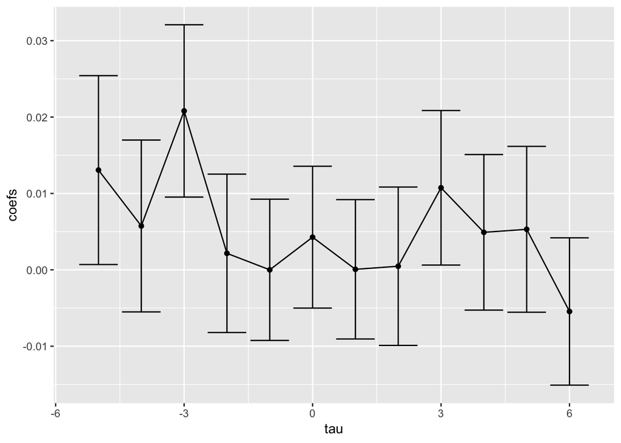

```r
for_normalization<-test_run$coefficients[paste0("`Tau_",zero_tau,"`TRUE")]
data.frame(coefs=test_run$coefficients-for_normalization,
           tau_string=names(test_run$coefficients),
           #specify range as 1.96*sd
           error=test_run$std.error*1.96)%>%
  #make tau numeric
  mutate(tau_string=gsub('`','',tau_string),
         tau=as.numeric(gsub('Tau_|TRUE','',tau_string,)))%>%
  ggplot(aes(x=tau,y=coefs))+
  geom_point(aes(x=tau,y=coefs))+
  geom_line()+
  geom_errorbar(aes(ymin=coefs-error,ymax=coefs+error))
```

```r
tau_minus_3<-for_event_study%>%
  filter(`Tau_-3`==1)
```